# Risk Factor Analysis

## Outcome Variable

**Outcome Variable:** ever_wasted

## Predictor Variables

**Intervention Variable:** mage

**Adjustment Set:**

unadjusted

## Stratifying Variables

The analysis was stratified on these variable(s):

- agecat
- studyid
- country

## Data Summary

| agecat | studyid | country | mage | ever_wasted | n_cell | n |
| --- | --- | --- | --- | --- | --- | --- |
| 0-24 months | ki0047075b-MAL-ED | BANGLADESH | <25 | 0 | 85 | 263 |
| 0-24 months | ki0047075b-MAL-ED | BANGLADESH | <25 | 1 | 39 | 263 |
| 0-24 months | ki0047075b-MAL-ED | BANGLADESH | [25-30) | 0 | 63 | 263 |
| 0-24 months | ki0047075b-MAL-ED | BANGLADESH | [25-30) | 1 | 30 | 263 |
| 0-24 months | ki0047075b-MAL-ED | BANGLADESH | >=30 | 0 | 28 | 263 |
| 0-24 months | ki0047075b-MAL-ED | BANGLADESH | >=30 | 1 | 18 | 263 |
| 0-24 months | ki0047075b-MAL-ED | BRAZIL | <25 | 0 | 110 | 233 |
| 0-24 months | ki0047075b-MAL-ED | BRAZIL | <25 | 1 | 7 | 233 |
| 0-24 months | ki0047075b-MAL-ED | BRAZIL | [25-30) | 0 | 57 | 233 |
| 0-24 months | ki0047075b-MAL-ED | BRAZIL | [25-30) | 1 | 8 | 233 |
| 0-24 months | ki0047075b-MAL-ED | BRAZIL | >=30 | 0 | 47 | 233 |
| 0-24 months | ki0047075b-MAL-ED | BRAZIL | >=30 | 1 | 4 | 233 |
| 0-24 months | ki0047075b-MAL-ED | INDIA | <25 | 0 | 76 | 249 |
| 0-24 months | ki0047075b-MAL-ED | INDIA | <25 | 1 | 69 | 249 |
| 0-24 months | ki0047075b-MAL-ED | INDIA | [25-30) | 0 | 41 | 249 |
| 0-24 months | ki0047075b-MAL-ED | INDIA | [25-30) | 1 | 42 | 249 |
| 0-24 months | ki0047075b-MAL-ED | INDIA | >=30 | 0 | 15 | 249 |
| 0-24 months | ki0047075b-MAL-ED | INDIA | >=30 | 1 | 6 | 249 |
| 0-24 months | ki0047075b-MAL-ED | NEPAL | <25 | 0 | 38 | 240 |
| 0-24 months | ki0047075b-MAL-ED | NEPAL | <25 | 1 | 28 | 240 |
| 0-24 months | ki0047075b-MAL-ED | NEPAL | [25-30) | 0 | 98 | 240 |
| 0-24 months | ki0047075b-MAL-ED | NEPAL | [25-30) | 1 | 30 | 240 |
| 0-24 months | ki0047075b-MAL-ED | NEPAL | >=30 | 0 | 35 | 240 |
| 0-24 months | ki0047075b-MAL-ED | NEPAL | >=30 | 1 | 11 | 240 |
| 0-24 months | ki0047075b-MAL-ED | PERU | <25 | 0 | 156 | 302 |
| 0-24 months | ki0047075b-MAL-ED | PERU | <25 | 1 | 15 | 302 |
| 0-24 months | ki0047075b-MAL-ED | PERU | [25-30) | 0 | 58 | 302 |
| 0-24 months | ki0047075b-MAL-ED | PERU | [25-30) | 1 | 6 | 302 |
| 0-24 months | ki0047075b-MAL-ED | PERU | >=30 | 0 | 62 | 302 |
| 0-24 months | ki0047075b-MAL-ED | PERU | >=30 | 1 | 5 | 302 |

[output cut: 450 more lines]

The following strata were considered:

- agecat: 0-24 months, studyid: ki0047075b-MAL-ED, country: BANGLADESH
- agecat: 0-24 months, studyid: ki0047075b-MAL-ED, country: BRAZIL
- agecat: 0-24 months, studyid: ki0047075b-MAL-ED, country: INDIA
- agecat: 0-24 months, studyid: ki0047075b-MAL-ED, country: NEPAL
- agecat: 0-24 months, studyid: ki0047075b-MAL-ED, country: PERU
- agecat: 0-24 months, studyid: ki0047075b-MAL-ED, country: SOUTH AFRICA
- agecat: 0-24 months, studyid: ki0047075b-MAL-ED, country: TANZANIA, UNITED REPUBLIC OF
- agecat: 0-24 months, studyid: ki1000108-CMC-V-BCS-2002, country: INDIA
- agecat: 0-24 months, studyid: ki1000108-IRC, country: INDIA
- agecat: 0-24 months, studyid: ki1000109-EE, country: PAKISTAN
- agecat: 0-24 months, studyid: ki1000304b-SAS-CompFeed, country: INDIA
- agecat: 0-24 months, studyid: ki1000304b-SAS-FoodSuppl, country: INDIA
- agecat: 0-24 months, studyid: ki1017093-NIH-Birth, country: BANGLADESH
- agecat: 0-24 months, studyid: ki1017093b-PROVIDE, country: BANGLADESH
- agecat: 0-24 months, studyid: ki1017093c-NIH-Crypto, country: BANGLADESH
- agecat: 0-24 months, studyid: ki1066203-TanzaniaChild2, country: TANZANIA, UNITED REPUBLIC OF
- agecat: 0-24 months, studyid: ki1101329-Keneba, country: GAMBIA
- agecat: 0-24 months, studyid: ki1112895-Guatemala BSC, country: GUATEMALA
- agecat: 0-24 months, studyid: ki1112895-iLiNS-Zinc, country: BURKINA FASO
- agecat: 0-24 months, studyid: ki1113344-GMS-Nepal, country: NEPAL
- agecat: 0-24 months, studyid: ki1119695-PROBIT, country: BELARUS
- agecat: 0-24 months, studyid: ki1126311-ZVITAMBO, country: ZIMBABWE
- agecat: 0-24 months, studyid: ki1135781-COHORTS, country: GUATEMALA
- agecat: 0-24 months, studyid: ki1135781-COHORTS, country: INDIA
- agecat: 0-24 months, studyid: ki1135781-COHORTS, country: PHILIPPINES
- agecat: 0-24 months, studyid: ki1148112-LCNI-5, country: MALAWI
- agecat: 0-24 months, studyid: kiGH5241-JiVitA-3, country: BANGLADESH
- agecat: 0-6 months, studyid: ki0047075b-MAL-ED, country: BANGLADESH
- agecat: 0-6 months, studyid: ki0047075b-MAL-ED, country: BRAZIL
- agecat: 0-6 months, studyid: ki0047075b-MAL-ED, country: INDIA
- agecat: 0-6 months, studyid: ki0047075b-MAL-ED, country: NEPAL
- agecat: 0-6 months, studyid: ki0047075b-MAL-ED, country: PERU
- agecat: 0-6 months, studyid: ki0047075b-MAL-ED, country: SOUTH AFRICA
- agecat: 0-6 months, studyid: ki0047075b-MAL-ED, country: TANZANIA, UNITED REPUBLIC OF
- agecat: 0-6 months, studyid: ki1000108-CMC-V-BCS-2002, country: INDIA
- agecat: 0-6 months, studyid: ki1000108-IRC, country: INDIA
- agecat: 0-6 months, studyid: ki1000109-EE, country: PAKISTAN
- agecat: 0-6 months, studyid: ki1000304b-SAS-CompFeed, country: INDIA
- agecat: 0-6 months, studyid: ki1000304b-SAS-FoodSuppl, country: INDIA
- agecat: 0-6 months, studyid: ki1017093-NIH-Birth, country: BANGLADESH
- agecat: 0-6 months, studyid: ki1017093b-PROVIDE, country: BANGLADESH
- agecat: 0-6 months, studyid: ki1017093c-NIH-Crypto, country: BANGLADESH
- agecat: 0-6 months, studyid: ki1066203-TanzaniaChild2, country: TANZANIA, UNITED REPUBLIC OF
- agecat: 0-6 months, studyid: ki1101329-Keneba, country: GAMBIA
- agecat: 0-6 months, studyid: ki1112895-Guatemala BSC, country: GUATEMALA
- agecat: 0-6 months, studyid: ki1113344-GMS-Nepal, country: NEPAL
- agecat: 0-6 months, studyid: ki1119695-PROBIT, country: BELARUS
- agecat: 0-6 months, studyid: ki1126311-ZVITAMBO, country: ZIMBABWE
- agecat: 0-6 months, studyid: ki1135781-COHORTS, country: GUATEMALA
- agecat: 0-6 months, studyid: ki1135781-COHORTS, country: INDIA
- agecat: 0-6 months, studyid: ki1135781-COHORTS, country: PHILIPPINES
- agecat: 0-6 months, studyid: ki1148112-LCNI-5, country: MALAWI
- agecat: 0-6 months, studyid: kiGH5241-JiVitA-3, country: BANGLADESH
- agecat: 6-24 months, studyid: ki0047075b-MAL-ED, country: BANGLADESH
- agecat: 6-24 months, studyid: ki0047075b-MAL-ED, country: BRAZIL
- agecat: 6-24 months, studyid: ki0047075b-MAL-ED, country: INDIA
- agecat: 6-24 months, studyid: ki0047075b-MAL-ED, country: NEPAL
- agecat: 6-24 months, studyid: ki0047075b-MAL-ED, country: PERU
- agecat: 6-24 months, studyid: ki0047075b-MAL-ED, country: SOUTH AFRICA
- agecat: 6-24 months, studyid: ki0047075b-MAL-ED, country: TANZANIA, UNITED REPUBLIC OF
- agecat: 6-24 months, studyid: ki1000108-CMC-V-BCS-2002, country: INDIA
- agecat: 6-24 months, studyid: ki1000108-IRC, country: INDIA
- agecat: 6-24 months, studyid: ki1000109-EE, country: PAKISTAN
- agecat: 6-24 months, studyid: ki1000304b-SAS-CompFeed, country: INDIA
- agecat: 6-24 months, studyid: ki1000304b-SAS-FoodSuppl, country: INDIA
- agecat: 6-24 months, studyid: ki1017093-NIH-Birth, country: BANGLADESH
- agecat: 6-24 months, studyid: ki1017093b-PROVIDE, country: BANGLADESH
- agecat: 6-24 months, studyid: ki1017093c-NIH-Crypto, country: BANGLADESH
- agecat: 6-24 months, studyid: ki1066203-TanzaniaChild2, country: TANZANIA, UNITED REPUBLIC OF
- agecat: 6-24 months, studyid: ki1101329-Keneba, country: GAMBIA
- agecat: 6-24 months, studyid: ki1112895-Guatemala BSC, country: GUATEMALA
- agecat: 6-24 months, studyid: ki1112895-iLiNS-Zinc, country: BURKINA FASO
- agecat: 6-24 months, studyid: ki1113344-GMS-Nepal, country: NEPAL
- agecat: 6-24 months, studyid: ki1119695-PROBIT, country: BELARUS
- agecat: 6-24 months, studyid: ki1126311-ZVITAMBO, country: ZIMBABWE
- agecat: 6-24 months, studyid: ki1135781-COHORTS, country: GUATEMALA
- agecat: 6-24 months, studyid: ki1135781-COHORTS, country: INDIA
- agecat: 6-24 months, studyid: ki1135781-COHORTS, country: PHILIPPINES
- agecat: 6-24 months, studyid: ki1148112-LCNI-5, country: MALAWI
- agecat: 6-24 months, studyid: kiGH5241-JiVitA-3, country: BANGLADESH

### Dropped Strata

Some strata were dropped due to rare outcomes:

- agecat: 0-24 months, studyid: ki0047075b-MAL-ED, country: BRAZIL
- agecat: 0-6 months, studyid: ki0047075b-MAL-ED, country: BRAZIL
- agecat: 0-6 months, studyid: ki0047075b-MAL-ED, country: PERU
- agecat: 0-6 months, studyid: ki0047075b-MAL-ED, country: TANZANIA, UNITED REPUBLIC OF
- agecat: 0-6 months, studyid: ki1112895-Guatemala BSC, country: GUATEMALA
- agecat: 0-6 months, studyid: ki1148112-LCNI-5, country: MALAWI
- agecat: 6-24 months, studyid: ki0047075b-MAL-ED, country: BRAZIL
- agecat: 6-24 months, studyid: ki0047075b-MAL-ED, country: INDIA
- agecat: 6-24 months, studyid: ki0047075b-MAL-ED, country: NEPAL
- agecat: 6-24 months, studyid: ki0047075b-MAL-ED, country: PERU
- agecat: 6-24 months, studyid: ki1112895-Guatemala BSC, country: GUATEMALA

## Methods Detail

We’re interested in the causal parameters $E[Y_a]$ for all values of $a \in \mathcal{A}$. These parameters represent the mean outcome if, possibly contrary to fact, we intervened to set all units to have $A=a$. Under the randomization and positivity assumptions, these are identified by the statistical parameters $\psi_a=E_W[E_{Y|A,W}(Y|A=a,W)]$. In addition, we’re interested in the mean of $Y$, $E[Y]$ under no intervention (the observed mean). We will estimate these parameters by using SuperLearner to fit the relevant likelihood factors – $E_{Y|A,W}(Y|A=a,W)$ and $p(A=a|W)$, and then updating our likelihood fit using a joint TMLE.

For unadjusted analyses ($W=\{\}$), initial likelihoods were estimated using Lrnr_glm to estimate the simple $E(Y|A)$ and Lrnr_mean to estimate $p(A)$. For adjusted analyses, a small library containing Lrnr_glmnet, Lrnr_xgboost, and Lrnr_mean was used.

Having estimated these parameters, we will then use the delta method to estimate relative risks and attributable risks relative to a prespecified baseline level of $A$.

# Results Detail

## Results Plots

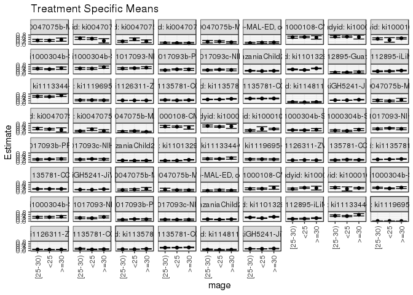

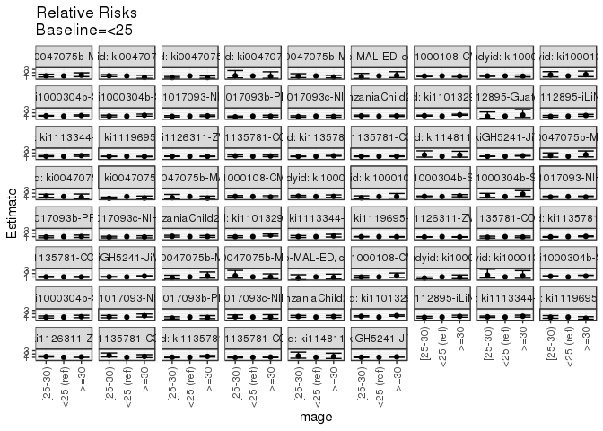

[figure not shown]

[figure not shown]

## Results Table

### Parameter: TSM

| agecat | studyid | country | intervention_level | baseline_level | estimate | ci_lower | ci_upper |
| --- | --- | --- | --- | --- | --- | --- | --- |
| 0-24 months | ki0047075b-MAL-ED | BANGLADESH | <25 | NA | 0.3145161 | 0.2326349 | 0.3963974 |
| 0-24 months | ki0047075b-MAL-ED | BANGLADESH | [25-30) | NA | 0.3225806 | 0.2273927 | 0.4177686 |
| 0-24 months | ki0047075b-MAL-ED | BANGLADESH | >=30 | NA | 0.3913043 | 0.2500005 | 0.5326081 |
| 0-24 months | ki0047075b-MAL-ED | INDIA | <25 | NA | 0.4758621 | 0.3944102 | 0.5573140 |
| 0-24 months | ki0047075b-MAL-ED | INDIA | [25-30) | NA | 0.5060241 | 0.3982483 | 0.6137999 |
| 0-24 months | ki0047075b-MAL-ED | INDIA | >=30 | NA | 0.2857143 | 0.0921103 | 0.4793182 |
| 0-24 months | ki0047075b-MAL-ED | NEPAL | <25 | NA | 0.4242424 | 0.3047584 | 0.5437264 |
| 0-24 months | ki0047075b-MAL-ED | NEPAL | [25-30) | NA | 0.2343750 | 0.1608367 | 0.3079133 |
| 0-24 months | ki0047075b-MAL-ED | NEPAL | >=30 | NA | 0.2391304 | 0.1156073 | 0.3626536 |
| 0-24 months | ki0047075b-MAL-ED | PERU | <25 | NA | 0.0877193 | 0.0452493 | 0.1301893 |
| 0-24 months | ki0047075b-MAL-ED | PERU | [25-30) | NA | 0.0937500 | 0.0222200 | 0.1652800 |
| 0-24 months | ki0047075b-MAL-ED | PERU | >=30 | NA | 0.0746269 | 0.0115984 | 0.1376554 |
| 0-24 months | ki0047075b-MAL-ED | SOUTH AFRICA | <25 | NA | 0.2214765 | 0.1546957 | 0.2882573 |
| 0-24 months | ki0047075b-MAL-ED | SOUTH AFRICA | [25-30) | NA | 0.2068966 | 0.1024792 | 0.3113139 |
| 0-24 months | ki0047075b-MAL-ED | SOUTH AFRICA | >=30 | NA | 0.1523810 | 0.0835290 | 0.2212329 |
| 0-24 months | ki0047075b-MAL-ED | TANZANIA, UNITED REPUBLIC OF | <25 | NA | 0.1279070 | 0.0571839 | 0.1986300 |
| 0-24 months | ki0047075b-MAL-ED | TANZANIA, UNITED REPUBLIC OF | [25-30) | NA | 0.0869565 | 0.0203443 | 0.1535687 |
| 0-24 months | ki0047075b-MAL-ED | TANZANIA, UNITED REPUBLIC OF | >=30 | NA | 0.1415094 | 0.0750297 | 0.2079892 |
| 0-24 months | ki1000108-CMC-V-BCS-2002 | INDIA | <25 | NA | 0.6244344 | 0.5605020 | 0.6883668 |
| 0-24 months | ki1000108-CMC-V-BCS-2002 | INDIA | [25-30) | NA | 0.6055046 | 0.5136296 | 0.6973796 |
| 0-24 months | ki1000108-CMC-V-BCS-2002 | INDIA | >=30 | NA | 0.5813953 | 0.4337450 | 0.7290457 |
| 0-24 months | ki1000108-IRC | INDIA | <25 | NA | 0.6589147 | 0.6009966 | 0.7168329 |
| 0-24 months | ki1000108-IRC | INDIA | [25-30) | NA | 0.6585366 | 0.5746316 | 0.7424416 |
| 0-24 months | ki1000108-IRC | INDIA | >=30 | NA | 0.6206897 | 0.4438767 | 0.7975026 |
| 0-24 months | ki1000109-EE | PAKISTAN | <25 | NA | 0.3636364 | 0.1623567 | 0.5649160 |
| 0-24 months | ki1000109-EE | PAKISTAN | [25-30) | NA | 0.4680851 | 0.3856146 | 0.5505556 |
| 0-24 months | ki1000109-EE | PAKISTAN | >=30 | NA | 0.5093458 | 0.4422783 | 0.5764133 |
| 0-24 months | ki1000304b-SAS-CompFeed | INDIA | <25 | NA | 0.3946237 | 0.3461812 | 0.4430661 |
| 0-24 months | ki1000304b-SAS-CompFeed | INDIA | [25-30) | NA | 0.4371981 | 0.3675098 | 0.5068864 |
| 0-24 months | ki1000304b-SAS-CompFeed | INDIA | >=30 | NA | 0.4733728 | 0.3676148 | 0.5791308 |

[output cut: 177 more lines]

### Parameter: E(Y)

| agecat | studyid | country | intervention_level | baseline_level | estimate | ci_lower | ci_upper |
| --- | --- | --- | --- | --- | --- | --- | --- |
| 0-24 months | ki0047075b-MAL-ED | BANGLADESH | NA | NA | 0.3307985 | 0.2738270 | 0.3877700 |
| 0-24 months | ki0047075b-MAL-ED | INDIA | NA | NA | 0.4698795 | 0.4077636 | 0.5319954 |
| 0-24 months | ki0047075b-MAL-ED | NEPAL | NA | NA | 0.2875000 | 0.2301200 | 0.3448800 |
| 0-24 months | ki0047075b-MAL-ED | PERU | NA | NA | 0.0860927 | 0.0544044 | 0.1177810 |
| 0-24 months | ki0047075b-MAL-ED | SOUTH AFRICA | NA | NA | 0.1955128 | 0.1514355 | 0.2395901 |
| 0-24 months | ki0047075b-MAL-ED | TANZANIA, UNITED REPUBLIC OF | NA | NA | 0.1226054 | 0.0827384 | 0.1624724 |
| 0-24 months | ki1000108-CMC-V-BCS-2002 | INDIA | NA | NA | 0.6139410 | 0.5644682 | 0.6634139 |
| 0-24 months | ki1000108-IRC | INDIA | NA | NA | 0.6560976 | 0.6100625 | 0.7021326 |
| 0-24 months | ki1000109-EE | PAKISTAN | NA | NA | 0.4854111 | 0.4348939 | 0.5359283 |
| 0-24 months | ki1000304b-SAS-CompFeed | INDIA | NA | NA | 0.4150694 | 0.3581204 | 0.4720184 |
| 0-24 months | ki1000304b-SAS-FoodSuppl | INDIA | NA | NA | 0.4712919 | 0.4233811 | 0.5192026 |
| 0-24 months | ki1017093-NIH-Birth | BANGLADESH | NA | NA | 0.4774920 | 0.4382065 | 0.5167774 |
| 0-24 months | ki1017093b-PROVIDE | BANGLADESH | NA | NA | 0.3514286 | 0.3160364 | 0.3868207 |
| 0-24 months | ki1017093c-NIH-Crypto | BANGLADESH | NA | NA | 0.3311346 | 0.2976093 | 0.3646598 |
| 0-24 months | ki1066203-TanzaniaChild2 | TANZANIA, UNITED REPUBLIC OF | NA | NA | 0.2369529 | 0.2198518 | 0.2540539 |
| 0-24 months | ki1101329-Keneba | GAMBIA | NA | NA | 0.3789731 | 0.3611996 | 0.3967466 |
| 0-24 months | ki1112895-Guatemala BSC | GUATEMALA | NA | NA | 0.1067616 | 0.0705906 | 0.1429325 |
| 0-24 months | ki1112895-iLiNS-Zinc | BURKINA FASO | NA | NA | 0.2271869 | 0.2003867 | 0.2539871 |
| 0-24 months | ki1113344-GMS-Nepal | NEPAL | NA | NA | 0.5913621 | 0.5520608 | 0.6306634 |
| 0-24 months | ki1119695-PROBIT | BELARUS | NA | NA | 0.2565984 | 0.1993515 | 0.3138454 |
| 0-24 months | ki1126311-ZVITAMBO | ZIMBABWE | NA | NA | 0.2345874 | 0.2275431 | 0.2416318 |
| 0-24 months | ki1135781-COHORTS | GUATEMALA | NA | NA | 0.2550336 | 0.2316956 | 0.2783715 |
| 0-24 months | ki1135781-COHORTS | INDIA | NA | NA | 0.3359095 | 0.3231988 | 0.3486203 |
| 0-24 months | ki1135781-COHORTS | PHILIPPINES | NA | NA | 0.4036125 | 0.3861835 | 0.4210415 |
| 0-24 months | ki1148112-LCNI-5 | MALAWI | NA | NA | 0.0805970 | 0.0599695 | 0.1012246 |
| 0-24 months | kiGH5241-JiVitA-3 | BANGLADESH | NA | NA | 0.2583210 | 0.2518556 | 0.2647863 |
| 0-6 months | ki0047075b-MAL-ED | BANGLADESH | NA | NA | 0.2243346 | 0.1738240 | 0.2748452 |
| 0-6 months | ki0047075b-MAL-ED | INDIA | NA | NA | 0.3132530 | 0.2555274 | 0.3709786 |
| 0-6 months | ki0047075b-MAL-ED | NEPAL | NA | NA | 0.1791667 | 0.1305478 | 0.2277856 |
| 0-6 months | ki0047075b-MAL-ED | SOUTH AFRICA | NA | NA | 0.1025641 | 0.0688457 | 0.1362825 |
| 0-6 months | ki1000108-CMC-V-BCS-2002 | INDIA | NA | NA | 0.5190217 | 0.4679041 | 0.5701394 |
| 0-6 months | ki1000108-IRC | INDIA | NA | NA | 0.5439024 | 0.4956326 | 0.5921723 |
| 0-6 months | ki1000109-EE | PAKISTAN | NA | NA | 0.2732095 | 0.2281687 | 0.3182504 |
| 0-6 months | ki1000304b-SAS-CompFeed | INDIA | NA | NA | 0.2199336 | 0.1753445 | 0.2645227 |
| 0-6 months | ki1000304b-SAS-FoodSuppl | INDIA | NA | NA | 0.1866029 | 0.1492099 | 0.2239959 |
| 0-6 months | ki1017093-NIH-Birth | BANGLADESH | NA | NA | 0.3580645 | 0.3202961 | 0.3958330 |
| 0-6 months | ki1017093b-PROVIDE | BANGLADESH | NA | NA | 0.2585714 | 0.2261125 | 0.2910304 |
| 0-6 months | ki1017093c-NIH-Crypto | BANGLADESH | NA | NA | 0.2585752 | 0.2273844 | 0.2897660 |
| 0-6 months | ki1066203-TanzaniaChild2 | TANZANIA, UNITED REPUBLIC OF | NA | NA | 0.1397306 | 0.1257869 | 0.1536744 |
| 0-6 months | ki1101329-Keneba | GAMBIA | NA | NA | 0.1598344 | 0.1452161 | 0.1744527 |
| 0-6 months | ki1113344-GMS-Nepal | NEPAL | NA | NA | 0.2956811 | 0.2591967 | 0.3321655 |
| 0-6 months | ki1119695-PROBIT | BELARUS | NA | NA | 0.2497780 | 0.1917926 | 0.3077635 |
| 0-6 months | ki1126311-ZVITAMBO | ZIMBABWE | NA | NA | 0.1808241 | 0.1744046 | 0.1872436 |
| 0-6 months | ki1135781-COHORTS | GUATEMALA | NA | NA | 0.2003763 | 0.1763021 | 0.2244505 |
| 0-6 months | ki1135781-COHORTS | INDIA | NA | NA | 0.2500980 | 0.2382136 | 0.2619824 |
| 0-6 months | ki1135781-COHORTS | PHILIPPINES | NA | NA | 0.2355453 | 0.2204685 | 0.2506222 |
| 0-6 months | kiGH5241-JiVitA-3 | BANGLADESH | NA | NA | 0.1763370 | 0.1707128 | 0.1819611 |
| 6-24 months | ki0047075b-MAL-ED | BANGLADESH | NA | NA | 0.1833333 | 0.1342773 | 0.2323893 |
| 6-24 months | ki0047075b-MAL-ED | SOUTH AFRICA | NA | NA | 0.1389961 | 0.0967835 | 0.1812087 |
| 6-24 months | ki0047075b-MAL-ED | TANZANIA, UNITED REPUBLIC OF | NA | NA | 0.1061224 | 0.0674772 | 0.1447677 |
| 6-24 months | ki1000108-CMC-V-BCS-2002 | INDIA | NA | NA | 0.2654155 | 0.2205451 | 0.3102860 |
| 6-24 months | ki1000108-IRC | INDIA | NA | NA | 0.3097561 | 0.2649438 | 0.3545684 |
| 6-24 months | ki1000109-EE | PAKISTAN | NA | NA | 0.3252688 | 0.2775985 | 0.3729391 |
| 6-24 months | ki1000304b-SAS-CompFeed | INDIA | NA | NA | 0.3059755 | 0.2638053 | 0.3481458 |
| 6-24 months | ki1000304b-SAS-FoodSuppl | INDIA | NA | NA | 0.3557214 | 0.3088651 | 0.4025777 |
| 6-24 months | ki1017093-NIH-Birth | BANGLADESH | NA | NA | 0.2931354 | 0.2546710 | 0.3315999 |
| 6-24 months | ki1017093b-PROVIDE | BANGLADESH | NA | NA | 0.1609756 | 0.1319065 | 0.1900447 |
| 6-24 months | ki1017093c-NIH-Crypto | BANGLADESH | NA | NA | 0.1315068 | 0.1069744 | 0.1560393 |
| 6-24 months | ki1066203-TanzaniaChild2 | TANZANIA, UNITED REPUBLIC OF | NA | NA | 0.1607589 | 0.1446692 | 0.1768485 |
| 6-24 months | ki1101329-Keneba | GAMBIA | NA | NA | 0.3205653 | 0.3029225 | 0.3382080 |
| 6-24 months | ki1112895-iLiNS-Zinc | BURKINA FASO | NA | NA | 0.2271869 | 0.2003867 | 0.2539871 |
| 6-24 months | ki1113344-GMS-Nepal | NEPAL | NA | NA | 0.4728814 | 0.4325613 | 0.5132014 |
| 6-24 months | ki1119695-PROBIT | BELARUS | NA | NA | 0.0100615 | 0.0072668 | 0.0128561 |
| 6-24 months | ki1126311-ZVITAMBO | ZIMBABWE | NA | NA | 0.0940195 | 0.0884810 | 0.0995580 |
| 6-24 months | ki1135781-COHORTS | GUATEMALA | NA | NA | 0.1269580 | 0.1082147 | 0.1457012 |
| 6-24 months | ki1135781-COHORTS | INDIA | NA | NA | 0.1317329 | 0.1223171 | 0.1411487 |
| 6-24 months | ki1135781-COHORTS | PHILIPPINES | NA | NA | 0.2666429 | 0.2502871 | 0.2829988 |
| 6-24 months | ki1148112-LCNI-5 | MALAWI | NA | NA | 0.0789074 | 0.0583085 | 0.0995064 |
| 6-24 months | kiGH5241-JiVitA-3 | BANGLADESH | NA | NA | 0.1641661 | 0.1580479 | 0.1702843 |

### Parameter: RR

| agecat | studyid | country | intervention_level | baseline_level | estimate | ci_lower | ci_upper |
| --- | --- | --- | --- | --- | --- | --- | --- |
| 0-24 months | ki0047075b-MAL-ED | BANGLADESH | <25 | <25 | 1.0000000 | 1.0000000 | 1.0000000 |
| 0-24 months | ki0047075b-MAL-ED | BANGLADESH | [25-30) | <25 | 1.0256410 | 0.6919835 | 1.5201800 |
| 0-24 months | ki0047075b-MAL-ED | BANGLADESH | >=30 | <25 | 1.2441472 | 0.7971432 | 1.9418118 |
| 0-24 months | ki0047075b-MAL-ED | INDIA | <25 | <25 | 1.0000000 | 1.0000000 | 1.0000000 |
| 0-24 months | ki0047075b-MAL-ED | INDIA | [25-30) | <25 | 1.0633840 | 0.8091383 | 1.3975182 |
| 0-24 months | ki0047075b-MAL-ED | INDIA | >=30 | <25 | 0.6004141 | 0.2984855 | 1.2077540 |
| 0-24 months | ki0047075b-MAL-ED | NEPAL | <25 | <25 | 1.0000000 | 1.0000000 | 1.0000000 |
| 0-24 months | ki0047075b-MAL-ED | NEPAL | [25-30) | <25 | 0.5524554 | 0.3623991 | 0.8421846 |
| 0-24 months | ki0047075b-MAL-ED | NEPAL | >=30 | <25 | 0.5636646 | 0.3129730 | 1.0151604 |
| 0-24 months | ki0047075b-MAL-ED | PERU | <25 | <25 | 1.0000000 | 1.0000000 | 1.0000000 |
| 0-24 months | ki0047075b-MAL-ED | PERU | [25-30) | <25 | 1.0687500 | 0.4329446 | 2.6382743 |
| 0-24 months | ki0047075b-MAL-ED | PERU | >=30 | <25 | 0.8507463 | 0.3213726 | 2.2521189 |
| 0-24 months | ki0047075b-MAL-ED | SOUTH AFRICA | <25 | <25 | 1.0000000 | 1.0000000 | 1.0000000 |
| 0-24 months | ki0047075b-MAL-ED | SOUTH AFRICA | [25-30) | <25 | 0.9341693 | 0.5189254 | 1.6816912 |
| 0-24 months | ki0047075b-MAL-ED | SOUTH AFRICA | >=30 | <25 | 0.6880231 | 0.3996590 | 1.1844491 |
| 0-24 months | ki0047075b-MAL-ED | TANZANIA, UNITED REPUBLIC OF | <25 | <25 | 1.0000000 | 1.0000000 | 1.0000000 |
| 0-24 months | ki0047075b-MAL-ED | TANZANIA, UNITED REPUBLIC OF | [25-30) | <25 | 0.6798419 | 0.2643078 | 1.7486620 |
| 0-24 months | ki0047075b-MAL-ED | TANZANIA, UNITED REPUBLIC OF | >=30 | <25 | 1.1063465 | 0.5355337 | 2.2855752 |
| 0-24 months | ki1000108-CMC-V-BCS-2002 | INDIA | <25 | <25 | 1.0000000 | 1.0000000 | 1.0000000 |
| 0-24 months | ki1000108-CMC-V-BCS-2002 | INDIA | [25-30) | <25 | 0.9696849 | 0.8074863 | 1.1644641 |
| 0-24 months | ki1000108-CMC-V-BCS-2002 | INDIA | >=30 | <25 | 0.9310752 | 0.7080535 | 1.2243439 |
| 0-24 months | ki1000108-IRC | INDIA | <25 | <25 | 1.0000000 | 1.0000000 | 1.0000000 |
| 0-24 months | ki1000108-IRC | INDIA | [25-30) | <25 | 0.9994261 | 0.8561035 | 1.1667427 |
| 0-24 months | ki1000108-IRC | INDIA | >=30 | <25 | 0.9419878 | 0.6991561 | 1.2691601 |
| 0-24 months | ki1000109-EE | PAKISTAN | <25 | <25 | 1.0000000 | 1.0000000 | 1.0000000 |
| 0-24 months | ki1000109-EE | PAKISTAN | [25-30) | <25 | 1.2872340 | 0.7200841 | 2.3010806 |
| 0-24 months | ki1000109-EE | PAKISTAN | >=30 | <25 | 1.4007009 | 0.7929522 | 2.4742513 |
| 0-24 months | ki1000304b-SAS-CompFeed | INDIA | <25 | <25 | 1.0000000 | 1.0000000 | 1.0000000 |
| 0-24 months | ki1000304b-SAS-CompFeed | INDIA | [25-30) | <25 | 1.1078861 | 1.0015263 | 1.2255411 |
| 0-24 months | ki1000304b-SAS-CompFeed | INDIA | >=30 | <25 | 1.1995550 | 1.0459772 | 1.3756822 |

[output cut: 177 more lines]

### Parameter: PAR

| agecat | studyid | country | intervention_level | baseline_level | estimate | ci_lower | ci_upper |
| --- | --- | --- | --- | --- | --- | --- | --- |
| 0-24 months | ki0047075b-MAL-ED | BANGLADESH | <25 | NA | 0.0162824 | -0.0439517 | 0.0765164 |
| 0-24 months | ki0047075b-MAL-ED | INDIA | <25 | NA | -0.0059826 | -0.0585751 | 0.0466100 |
| 0-24 months | ki0047075b-MAL-ED | NEPAL | <25 | NA | -0.1367424 | -0.2353165 | -0.0381683 |
| 0-24 months | ki0047075b-MAL-ED | PERU | <25 | NA | -0.0016266 | -0.0292897 | 0.0260365 |
| 0-24 months | ki0047075b-MAL-ED | SOUTH AFRICA | <25 | NA | -0.0259637 | -0.0722554 | 0.0203280 |
| 0-24 months | ki0047075b-MAL-ED | TANZANIA, UNITED REPUBLIC OF | <25 | NA | -0.0053016 | -0.0627033 | 0.0521001 |
| 0-24 months | ki1000108-CMC-V-BCS-2002 | INDIA | <25 | NA | -0.0104934 | -0.0516207 | 0.0306339 |
| 0-24 months | ki1000108-IRC | INDIA | <25 | NA | -0.0028172 | -0.0382002 | 0.0325659 |
| 0-24 months | ki1000109-EE | PAKISTAN | <25 | NA | 0.1217748 | -0.0740239 | 0.3175734 |
| 0-24 months | ki1000304b-SAS-CompFeed | INDIA | <25 | NA | 0.0204457 | 0.0027954 | 0.0380961 |
| 0-24 months | ki1000304b-SAS-FoodSuppl | INDIA | <25 | NA | 0.0310745 | -0.0228914 | 0.0850404 |
| 0-24 months | ki1017093-NIH-Birth | BANGLADESH | <25 | NA | 0.0017638 | -0.0377750 | 0.0413026 |
| 0-24 months | ki1017093b-PROVIDE | BANGLADESH | <25 | NA | -0.0225552 | -0.0560231 | 0.0109128 |
| 0-24 months | ki1017093c-NIH-Crypto | BANGLADESH | <25 | NA | -0.0172364 | -0.0489925 | 0.0145198 |
| 0-24 months | ki1066203-TanzaniaChild2 | TANZANIA, UNITED REPUBLIC OF | <25 | NA | 0.0142502 | -0.0070022 | 0.0355025 |
| 0-24 months | ki1101329-Keneba | GAMBIA | <25 | NA | 0.0614172 | 0.0401846 | 0.0826498 |
| 0-24 months | ki1112895-Guatemala BSC | GUATEMALA | <25 | NA | 0.0054957 | -0.0266250 | 0.0376165 |
| 0-24 months | ki1112895-iLiNS-Zinc | BURKINA FASO | <25 | NA | 0.0124218 | -0.0172489 | 0.0420925 |
| 0-24 months | ki1113344-GMS-Nepal | NEPAL | <25 | NA | 0.0237946 | -0.0114629 | 0.0590520 |
| 0-24 months | ki1119695-PROBIT | BELARUS | <25 | NA | -0.0035482 | -0.0107074 | 0.0036111 |
| 0-24 months | ki1126311-ZVITAMBO | ZIMBABWE | <25 | NA | 0.0000714 | -0.0058999 | 0.0060428 |
| 0-24 months | ki1135781-COHORTS | GUATEMALA | <25 | NA | 0.0157478 | -0.0116492 | 0.0431449 |
| 0-24 months | ki1135781-COHORTS | INDIA | <25 | NA | 0.0098990 | -0.0047371 | 0.0245350 |
| 0-24 months | ki1135781-COHORTS | PHILIPPINES | <25 | NA | 0.0000384 | -0.0195822 | 0.0196590 |
| 0-24 months | ki1148112-LCNI-5 | MALAWI | <25 | NA | 0.0141518 | -0.0083418 | 0.0366454 |
| 0-24 months | kiGH5241-JiVitA-3 | BANGLADESH | <25 | NA | 0.0037535 | 0.0004854 | 0.0070216 |
| 0-6 months | ki0047075b-MAL-ED | BANGLADESH | <25 | NA | 0.0307862 | -0.0223943 | 0.0839667 |
| 0-6 months | ki0047075b-MAL-ED | INDIA | <25 | NA | 0.0098047 | -0.0392512 | 0.0588606 |
| 0-6 months | ki0047075b-MAL-ED | NEPAL | <25 | NA | -0.1087121 | -0.1967786 | -0.0206457 |
| 0-6 months | ki0047075b-MAL-ED | SOUTH AFRICA | <25 | NA | -0.0316641 | -0.0673265 | 0.0039983 |
| 0-6 months | ki1000108-CMC-V-BCS-2002 | INDIA | <25 | NA | -0.0015262 | -0.0436926 | 0.0406402 |
| 0-6 months | ki1000108-IRC | INDIA | <25 | NA | 0.0206466 | -0.0163311 | 0.0576243 |
| 0-6 months | ki1000109-EE | PAKISTAN | <25 | NA | -0.0449723 | -0.2335916 | 0.1436470 |
| 0-6 months | ki1000304b-SAS-CompFeed | INDIA | <25 | NA | 0.0082705 | -0.0032319 | 0.0197729 |
| 0-6 months | ki1000304b-SAS-FoodSuppl | INDIA | <25 | NA | 0.0344290 | -0.0070585 | 0.0759164 |
| 0-6 months | ki1017093-NIH-Birth | BANGLADESH | <25 | NA | -0.0263003 | -0.0644468 | 0.0118462 |
| 0-6 months | ki1017093b-PROVIDE | BANGLADESH | <25 | NA | -0.0043012 | -0.0350245 | 0.0264221 |
| 0-6 months | ki1017093c-NIH-Crypto | BANGLADESH | <25 | NA | -0.0171140 | -0.0466315 | 0.0124035 |
| 0-6 months | ki1066203-TanzaniaChild2 | TANZANIA, UNITED REPUBLIC OF | <25 | NA | 0.0067577 | -0.0105764 | 0.0240917 |
| 0-6 months | ki1101329-Keneba | GAMBIA | <25 | NA | 0.0221459 | 0.0049879 | 0.0393039 |
| 0-6 months | ki1113344-GMS-Nepal | NEPAL | <25 | NA | 0.0103958 | -0.0224772 | 0.0432688 |
| 0-6 months | ki1119695-PROBIT | BELARUS | <25 | NA | -0.0030943 | -0.0105413 | 0.0043527 |
| 0-6 months | ki1126311-ZVITAMBO | ZIMBABWE | <25 | NA | -0.0064581 | -0.0118697 | -0.0010466 |
| 0-6 months | ki1135781-COHORTS | GUATEMALA | <25 | NA | -0.0152635 | -0.0452146 | 0.0146876 |
| 0-6 months | ki1135781-COHORTS | INDIA | <25 | NA | -0.0000169 | -0.0138037 | 0.0137698 |
| 0-6 months | ki1135781-COHORTS | PHILIPPINES | <25 | NA | -0.0004934 | -0.0174637 | 0.0164770 |
| 0-6 months | kiGH5241-JiVitA-3 | BANGLADESH | <25 | NA | 0.0050413 | 0.0021449 | 0.0079378 |
| 6-24 months | ki0047075b-MAL-ED | BANGLADESH | <25 | NA | -0.0041667 | -0.0566671 | 0.0483338 |
| 6-24 months | ki0047075b-MAL-ED | SOUTH AFRICA | <25 | NA | 0.0056628 | -0.0396619 | 0.0509875 |
| 6-24 months | ki0047075b-MAL-ED | TANZANIA, UNITED REPUBLIC OF | <25 | NA | -0.0237477 | -0.0837145 | 0.0362192 |
| 6-24 months | ki1000108-CMC-V-BCS-2002 | INDIA | <25 | NA | 0.0074970 | -0.0298698 | 0.0448638 |
| 6-24 months | ki1000108-IRC | INDIA | <25 | NA | -0.0352051 | -0.0689125 | -0.0014978 |
| 6-24 months | ki1000109-EE | PAKISTAN | <25 | NA | 0.0871736 | -0.0911217 | 0.2654688 |
| 6-24 months | ki1000304b-SAS-CompFeed | INDIA | <25 | NA | 0.0218976 | 0.0033805 | 0.0404148 |
| 6-24 months | ki1000304b-SAS-FoodSuppl | INDIA | <25 | NA | 0.0054389 | -0.0473508 | 0.0582286 |
| 6-24 months | ki1017093-NIH-Birth | BANGLADESH | <25 | NA | 0.0305872 | -0.0093077 | 0.0704821 |
| 6-24 months | ki1017093b-PROVIDE | BANGLADESH | <25 | NA | -0.0199768 | -0.0482762 | 0.0083226 |
| 6-24 months | ki1017093c-NIH-Crypto | BANGLADESH | <25 | NA | 0.0035695 | -0.0198096 | 0.0269486 |
| 6-24 months | ki1066203-TanzaniaChild2 | TANZANIA, UNITED REPUBLIC OF | <25 | NA | 0.0158313 | -0.0044374 | 0.0361001 |
| 6-24 months | ki1101329-Keneba | GAMBIA | <25 | NA | 0.0562191 | 0.0348074 | 0.0776307 |
| 6-24 months | ki1112895-iLiNS-Zinc | BURKINA FASO | <25 | NA | 0.0124218 | -0.0172489 | 0.0420925 |
| 6-24 months | ki1113344-GMS-Nepal | NEPAL | <25 | NA | 0.0267275 | -0.0097167 | 0.0631717 |
| 6-24 months | ki1119695-PROBIT | BELARUS | <25 | NA | -0.0007608 | -0.0023738 | 0.0008522 |
| 6-24 months | ki1126311-ZVITAMBO | ZIMBABWE | <25 | NA | 0.0070772 | 0.0022266 | 0.0119279 |
| 6-24 months | ki1135781-COHORTS | GUATEMALA | <25 | NA | 0.0231655 | 0.0013601 | 0.0449710 |
| 6-24 months | ki1135781-COHORTS | INDIA | <25 | NA | 0.0095846 | -0.0012894 | 0.0204586 |
| 6-24 months | ki1135781-COHORTS | PHILIPPINES | <25 | NA | 0.0031021 | -0.0153212 | 0.0215255 |
| 6-24 months | ki1148112-LCNI-5 | MALAWI | <25 | NA | 0.0104143 | -0.0123890 | 0.0332176 |
| 6-24 months | kiGH5241-JiVitA-3 | BANGLADESH | <25 | NA | 0.0020394 | -0.0011687 | 0.0052474 |

### Parameter: PAF

| agecat | studyid | country | intervention_level | baseline_level | estimate | ci_lower | ci_upper |
| --- | --- | --- | --- | --- | --- | --- | --- |
| 0-24 months | ki0047075b-MAL-ED | BANGLADESH | <25 | NA | 0.0492214 | -0.1514556 | 0.2149241 |
| 0-24 months | ki0047075b-MAL-ED | INDIA | <25 | NA | -0.0127321 | -0.1310904 | 0.0932411 |
| 0-24 months | ki0047075b-MAL-ED | NEPAL | <25 | NA | -0.4756258 | -0.8647535 | -0.1676994 |
| 0-24 months | ki0047075b-MAL-ED | PERU | <25 | NA | -0.0188934 | -0.3965670 | 0.2566460 |
| 0-24 months | ki0047075b-MAL-ED | SOUTH AFRICA | <25 | NA | -0.1327979 | -0.3950809 | 0.0801745 |
| 0-24 months | ki0047075b-MAL-ED | TANZANIA, UNITED REPUBLIC OF | <25 | NA | -0.0432413 | -0.6338939 | 0.3338904 |
| 0-24 months | ki1000108-CMC-V-BCS-2002 | INDIA | <25 | NA | -0.0170918 | -0.0863699 | 0.0477684 |
| 0-24 months | ki1000108-IRC | INDIA | <25 | NA | -0.0042938 | -0.0597001 | 0.0482156 |
| 0-24 months | ki1000109-EE | PAKISTAN | <25 | NA | 0.2508693 | -0.2841158 | 0.5629703 |
| 0-24 months | ki1000304b-SAS-CompFeed | INDIA | <25 | NA | 0.0492586 | 0.0096142 | 0.0873160 |
| 0-24 months | ki1000304b-SAS-FoodSuppl | INDIA | <25 | NA | 0.0659347 | -0.0560335 | 0.1738160 |
| 0-24 months | ki1017093-NIH-Birth | BANGLADESH | <25 | NA | 0.0036939 | -0.0826502 | 0.0831519 |
| 0-24 months | ki1017093b-PROVIDE | BANGLADESH | <25 | NA | -0.0641814 | -0.1638435 | 0.0269465 |
| 0-24 months | ki1017093c-NIH-Crypto | BANGLADESH | <25 | NA | -0.0520524 | -0.1524671 | 0.0396131 |
| 0-24 months | ki1066203-TanzaniaChild2 | TANZANIA, UNITED REPUBLIC OF | <25 | NA | 0.0601392 | -0.0339219 | 0.1456431 |
| 0-24 months | ki1101329-Keneba | GAMBIA | <25 | NA | 0.1620621 | 0.1041074 | 0.2162677 |
| 0-24 months | ki1112895-Guatemala BSC | GUATEMALA | <25 | NA | 0.0514768 | -0.3020389 | 0.3090097 |
| 0-24 months | ki1112895-iLiNS-Zinc | BURKINA FASO | <25 | NA | 0.0546766 | -0.0868438 | 0.1777694 |
| 0-24 months | ki1113344-GMS-Nepal | NEPAL | <25 | NA | 0.0402369 | -0.0213880 | 0.0981436 |
| 0-24 months | ki1119695-PROBIT | BELARUS | <25 | NA | -0.0138277 | -0.0424659 | 0.0140237 |
| 0-24 months | ki1126311-ZVITAMBO | ZIMBABWE | <25 | NA | 0.0003045 | -0.0254771 | 0.0254379 |
| 0-24 months | ki1135781-COHORTS | GUATEMALA | <25 | NA | 0.0617481 | -0.0520088 | 0.1632042 |
| 0-24 months | ki1135781-COHORTS | INDIA | <25 | NA | 0.0294692 | -0.0150948 | 0.0720767 |
| 0-24 months | ki1135781-COHORTS | PHILIPPINES | <25 | NA | 0.0000951 | -0.0497185 | 0.0475449 |
| 0-24 months | ki1148112-LCNI-5 | MALAWI | <25 | NA | 0.1755875 | -0.1521952 | 0.4101209 |
| 0-24 months | kiGH5241-JiVitA-3 | BANGLADESH | <25 | NA | 0.0145304 | 0.0017908 | 0.0271073 |
| 0-6 months | ki0047075b-MAL-ED | BANGLADESH | <25 | NA | 0.1372335 | -0.1342629 | 0.3437447 |
| 0-6 months | ki0047075b-MAL-ED | INDIA | <25 | NA | 0.0312997 | -0.1386561 | 0.1758880 |
| 0-6 months | ki0047075b-MAL-ED | NEPAL | <25 | NA | -0.6067653 | -1.1705268 | -0.1894323 |
| 0-6 months | ki0047075b-MAL-ED | SOUTH AFRICA | <25 | NA | -0.3087248 | -0.6933064 | -0.0114889 |
| 0-6 months | ki1000108-CMC-V-BCS-2002 | INDIA | <25 | NA | -0.0029405 | -0.0875644 | 0.0750987 |
| 0-6 months | ki1000108-IRC | INDIA | <25 | NA | 0.0379602 | -0.0326014 | 0.1037000 |
| 0-6 months | ki1000109-EE | PAKISTAN | <25 | NA | -0.1646072 | -1.1067161 | 0.3561971 |
| 0-6 months | ki1000304b-SAS-CompFeed | INDIA | <25 | NA | 0.0376045 | -0.0124669 | 0.0851996 |
| 0-6 months | ki1000304b-SAS-FoodSuppl | INDIA | <25 | NA | 0.1845039 | -0.0685509 | 0.3776302 |
| 0-6 months | ki1017093-NIH-Birth | BANGLADESH | <25 | NA | -0.0734513 | -0.1855139 | 0.0280184 |
| 0-6 months | ki1017093b-PROVIDE | BANGLADESH | <25 | NA | -0.0166345 | -0.1426699 | 0.0954993 |
| 0-6 months | ki1017093c-NIH-Crypto | BANGLADESH | <25 | NA | -0.0661859 | -0.1865959 | 0.0420055 |
| 0-6 months | ki1066203-TanzaniaChild2 | TANZANIA, UNITED REPUBLIC OF | <25 | NA | 0.0483621 | -0.0840659 | 0.1646129 |
| 0-6 months | ki1101329-Keneba | GAMBIA | <25 | NA | 0.1385555 | 0.0248022 | 0.2390399 |
| 0-6 months | ki1113344-GMS-Nepal | NEPAL | <25 | NA | 0.0351588 | -0.0826591 | 0.1401554 |
| 0-6 months | ki1119695-PROBIT | BELARUS | <25 | NA | -0.0123881 | -0.0429681 | 0.0172954 |
| 0-6 months | ki1126311-ZVITAMBO | ZIMBABWE | <25 | NA | -0.0357150 | -0.0660637 | -0.0062302 |
| 0-6 months | ki1135781-COHORTS | GUATEMALA | <25 | NA | -0.0761743 | -0.2363787 | 0.0632716 |
| 0-6 months | ki1135781-COHORTS | INDIA | <25 | NA | -0.0000677 | -0.0567408 | 0.0535659 |
| 0-6 months | ki1135781-COHORTS | PHILIPPINES | <25 | NA | -0.0020946 | -0.0767948 | 0.0674233 |
| 0-6 months | kiGH5241-JiVitA-3 | BANGLADESH | <25 | NA | 0.0285893 | 0.0120527 | 0.0448491 |
| 6-24 months | ki0047075b-MAL-ED | BANGLADESH | <25 | NA | -0.0227273 | -0.3531580 | 0.2270148 |
| 6-24 months | ki0047075b-MAL-ED | SOUTH AFRICA | <25 | NA | 0.0407407 | -0.3473936 | 0.3170679 |
| 6-24 months | ki0047075b-MAL-ED | TANZANIA, UNITED REPUBLIC OF | <25 | NA | -0.2237762 | -0.9353094 | 0.2261556 |
| 6-24 months | ki1000108-CMC-V-BCS-2002 | INDIA | <25 | NA | 0.0282463 | -0.1232211 | 0.1592881 |
| 6-24 months | ki1000108-IRC | INDIA | <25 | NA | -0.1136544 | -0.2279668 | -0.0099834 |
| 6-24 months | ki1000109-EE | PAKISTAN | <25 | NA | 0.2680047 | -0.5469618 | 0.6536326 |
| 6-24 months | ki1000304b-SAS-CompFeed | INDIA | <25 | NA | 0.0715666 | 0.0129682 | 0.1266861 |
| 6-24 months | ki1000304b-SAS-FoodSuppl | INDIA | <25 | NA | 0.0152898 | -0.1448794 | 0.1530512 |
| 6-24 months | ki1017093-NIH-Birth | BANGLADESH | <25 | NA | 0.1043449 | -0.0424305 | 0.2304541 |
| 6-24 months | ki1017093b-PROVIDE | BANGLADESH | <25 | NA | -0.1240981 | -0.3134381 | 0.0379474 |
| 6-24 months | ki1017093c-NIH-Crypto | BANGLADESH | <25 | NA | 0.0271432 | -0.1678542 | 0.1895817 |
| 6-24 months | ki1066203-TanzaniaChild2 | TANZANIA, UNITED REPUBLIC OF | <25 | NA | 0.0984787 | -0.0365550 | 0.2159213 |
| 6-24 months | ki1101329-Keneba | GAMBIA | <25 | NA | 0.1753748 | 0.1059697 | 0.2393919 |
| 6-24 months | ki1112895-iLiNS-Zinc | BURKINA FASO | <25 | NA | 0.0546766 | -0.0868438 | 0.1777694 |
| 6-24 months | ki1113344-GMS-Nepal | NEPAL | <25 | NA | 0.0565205 | -0.0238962 | 0.1306214 |
| 6-24 months | ki1119695-PROBIT | BELARUS | <25 | NA | -0.0756169 | -0.2475406 | 0.0726139 |
| 6-24 months | ki1126311-ZVITAMBO | ZIMBABWE | <25 | NA | 0.0752742 | 0.0223794 | 0.1253071 |
| 6-24 months | ki1135781-COHORTS | GUATEMALA | <25 | NA | 0.1824662 | -0.0066672 | 0.3360651 |
| 6-24 months | ki1135781-COHORTS | INDIA | <25 | NA | 0.0727579 | -0.0134451 | 0.1516286 |
| 6-24 months | ki1135781-COHORTS | PHILIPPINES | <25 | NA | 0.0116339 | -0.0599310 | 0.0783669 |
| 6-24 months | ki1148112-LCNI-5 | MALAWI | <25 | NA | 0.1319810 | -0.2084829 | 0.3765266 |
| 6-24 months | kiGH5241-JiVitA-3 | BANGLADESH | <25 | NA | 0.0124226 | -0.0073104 | 0.0317690 |